# 🐍 Programming Assignment V: Data Analysis; Titanic Dataset

In this assignment, you'll apply your data analysis skills to the famous Titanic dataset.

You will use the `pandas` and `matplotlib` libraries to explore, analyze, and visualize information about passengers on the Titanic.

The dataset file is **`titanic.csv`**.

Make sure to run all cells and save your notebook before submitting.

## Exercise 1: Load and Preview the Data

Write code to load the dataset `titanic.csv` using `pandas.read_csv()`. Then display:

- The first 5 rows of the dataset
- The shape of the DataFrame
- The column names

```python
import pandas as pd
import matplotlib.pyplot as plt
```

```python
df = pd.read_csv('data/titanic.csv') #labels df as a quick hot key to read the file
```

```python
#Displays the first 5 rows
print("First 5 rows:")
print(df.head())

# Display the shape of the DataFrame
print("\nShape of the DataFrame:")
print(df.shape)

# Display the column names
print("\nColumn names:")
print(df.columns.tolist())
```

```
First 5 rows:
   PassengerId  Survived  Pclass  \
0            1         0       3
1            2         1       1
2            3         1       3
3            4         1       1
4            5         0       3

                                                Name     Sex   Age  SibSp  \
0                            Braund, Mr. Owen Harris    male  22.0      1
1  Cumings, Mrs. John Bradley (Florence Briggs Th...  female  38.0      1
2                             Heikkinen, Miss. Laina  female  26.0      0
3       Futrelle, Mrs. Jacques Heath (Lily May Peel)  female  35.0      1
4                           Allen, Mr. William Henry    male  35.0      0

   Parch            Ticket     Fare Cabin Embarked
0      0         A/5 21171   7.2500   NaN        S
1      0          PC 17599  71.2833   C85        C
2      0  STON/O2. 3101282   7.9250   NaN        S
3      0            113803  53.1000  C123        S
4      0            373450   8.0500   NaN        S

Shape of the DataFrame:
(891, 12)

Column names:
['PassengerId', 'Survived', 'Pclass', 'Name', 'Sex', 'Age', 'SibSp', 'Parch', 'Ticket', 'Fare', 'Cabin', 'Embarked']
```

## Exercise 2: Summary Statistics

Display summary statistics for numerical columns in the dataset. Then:

- Print the average age and fare
- Count how many passengers were in each passenger class (`Pclass`)

```python
# Summary statistics for numerical columns
print("Summary statistics:")
print(df.describe())

# Print average age and fare
print("\nAverage Age:", df["Age"].mean())
print("Average Fare:", df["Fare"].mean())

# Count how many passengers were in each passenger class
print("\nPassenger count per class:")
print(df["Pclass"].value_counts())
```

```
Summary statistics:
       PassengerId    Survived      Pclass         Age       SibSp  \
count   891.000000  891.000000  891.000000  714.000000  891.000000
mean    446.000000    0.383838    2.308642   29.699118    0.523008
std     257.353842    0.486592    0.836071   14.526497    1.102743
min       1.000000    0.000000    1.000000    0.420000    0.000000
25%     223.500000    0.000000    2.000000   20.125000    0.000000
50%     446.000000    0.000000    3.000000   28.000000    0.000000
75%     668.500000    1.000000    3.000000   38.000000    1.000000
max     891.000000    1.000000    3.000000   80.000000    8.000000

            Parch        Fare
count  891.000000  891.000000
mean     0.381594   32.204208
std      0.806057   49.693429
min      0.000000    0.000000
25%      0.000000    7.910400
50%      0.000000   14.454200
75%      0.000000   31.000000
max      6.000000  512.329200

Average Age: 29.69911764705882
Average Fare: 32.204207968574636

Passenger count per class:
Pclass
3    491
1    216
2    184
Name: count, dtype: int64
```

## Exercise 3: Data Filtering

Write code to display all passengers who meet the following criteria:

- Are female
- Are younger than 20
- Embarked from port 'S'

```python
# Filter the DataFrame
filtered_passengers = df[
    (df["Sex"] == "female") &
    (df["Age"] < 20) &
    (df["Embarked"] == "S")
]

# Display the result
print(filtered_passengers)
```

```
     PassengerId  Survived  Pclass  \
10            11         1       3
14            15         0       3
24            25         0       3
38            39         0       3
49            50         0       3
58            59         1       2
68            69         1       3
71            72         0       3
84            85         1       2
119          120         0       3
136          137         1       1
147          148         0       3
172          173         1       3
184          185         1       3
```

[output cut: 137 more lines]

## Exercise 4: Visualization by Class

Create a bar chart showing the **average survival rate** for each passenger class (`Pclass`).

Use `groupby()` and `matplotlib.pyplot` to do this. Label your axes clearly.

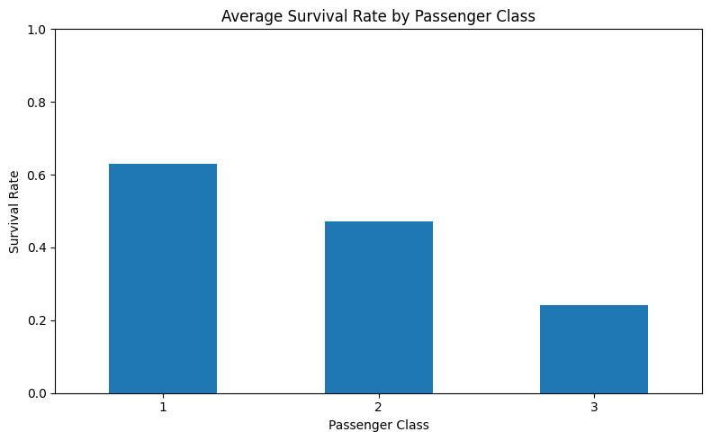

```python
# Group by Pclass and calculate average survival rate
avg_survival = df.groupby("Pclass")["Survived"].mean()

# Plot the bar chart
plt.figure(figsize=(8, 5))
avg_survival.plot(kind="bar")

# Labeling
plt.title("Average Survival Rate by Passenger Class")
plt.xlabel("Passenger Class")
plt.ylabel("Survival Rate")
plt.xticks(rotation=0)
plt.ylim(0, 1)  # Survival rate between 0 and 1

# Show the chart
plt.tight_layout()
plt.show()
```

## Exercise 5: Correlation Analysis

Use `.corr()` to compute the correlation matrix for the following features: `Age`, `Fare`, `Pclass`, `Survived`. Then display the matrix as a heatmap using `matplotlib.pyplot.imshow()`.

In a comment, describe which feature has the strongest positive correlation with survival.

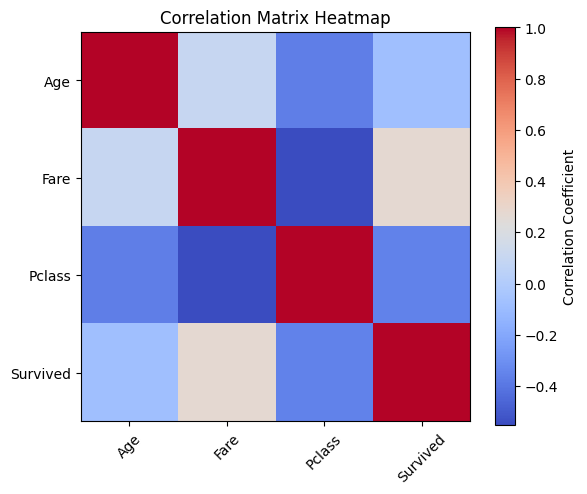

```python
# relevant features
features = df[["Age", "Fare", "Pclass", "Survived"]]

# Drop rows with missing values in selected columns
features = features.dropna()

# Compute correlation matrix
corr_matrix = features.corr()

# Show the matrix as a heatmap
plt.figure(figsize=(6, 5))
plt.imshow(corr_matrix, cmap='coolwarm', interpolation='none')
plt.colorbar(label="Correlation Coefficient")

# Label axes
plt.xticks(range(len(corr_matrix.columns)), corr_matrix.columns, rotation=45)
plt.yticks(range(len(corr_matrix.index)), corr_matrix.index)

# Title
plt.title("Correlation Matrix Heatmap")
plt.tight_layout()
plt.show()
```

## The feature that showed me the most relevance in the survival of the passangers was the Fare.

## The more you paid for your ticket, the more safety assurance you were going to have in case of an emergency.

## Tough world they lived in.